# Machine Learning Assignment

Karin

22 September 2015

# Executive Summary

The goal of this project is to predict how well the participants did the exercise on data obtained from this link http://groupware.les.inf.puc-rio.br/har. Greatly appreciated your generosity to make this data and paper available for us to learn. Refer to reference on details of the authors.

This paper will describe which processes were followed to determine the best model to apply to the test data and how the process were conducted.

## Getting the data

The data consists of two csv files.

```r
training <- read.csv("pml-training.csv")
testing <- read.csv("pml-testing.csv")
```

## Cleaning the data

```r
#determine columns with values
training_filter_col <- training[,(colSums(is.na(training)) == 0)]
testing_filter_col <- testing[,(colSums(is.na(testing)) == 0)]
#Remove columns with no values
removeCol <- c("X","user_name","raw_timestamp_part_1","raw_timestamp_part_2","cvtd_timestamp","new_window")
NewTrain <- training_filter_col[,!(names(training_filter_col) %in% removeCol)]
NewTest <- testing_filter_col[,!(names(testing_filter_col) %in% removeCol)]
```

### Removing irrelevant variables

The process of excluding near zero variance features will be used to remove variables that should not be included in the training of any models.

The training data (NewTrain) is then split into a validation data set (FinalValid) on which the models will be tested before the final test will be run on the test set. 30% of the data will be allocated to the validation data.The remainder of the training data (FinalTrain) will be used to train the models.

The reason for splitting the data, is because I selected the approach to build different models and need the validation data to test each of the models on before applying the best fit model to the original test set.

```r
library(caret)
nzvcol <- nearZeroVar(NewTrain)
NewTrain <- NewTrain[, -nzvcol]

#Split training data into training and validation sets
inTrain <- createDataPartition(y=NewTrain$classe,
                               p=0.7, list=FALSE)
FinalTrain <- NewTrain[inTrain,]
FinalValid <- NewTrain[-inTrain,]
```

## Machine Learning

### Cross validation

The next section of this document will describe which models were selected and how the data trained into different models, to get to a point of selecting the best model fit.

I have opted to use the random forest model, Recursive Partition model and Naive Bayes model as the three contenders to find the best model, with the possibilty that if neither one give an acceptable accuracy, I will consider blending these models.

Due to very long run times and a complete memory loss on my laptop, I did some research on how to improve this. The train control does exactly that. I used suggestions from stackoverflow.com to set these parameters.

I have set the training control using the repeated K-fold cross validation for the recursive partition models, because I saw in two documents that this is a very reliable and preferred method to do cross validation on. Refer to references for recommendations on the repeated K-fold cross validation.

```r
#Traincontrol for RPart - use recommended repeated K-fold cross validation
train_ctrl <- trainControl(method = "repeatedcv",
                           number = 10,
                           repeats = 3)

#Train Recursive Partition model - 2min
modelRpart <- train(classe ~ ., data = FinalTrain,
                    method = "rpart",
                    tuneLength = 30,
                    metric = "Accuracy",
                    trControl = train_ctrl)
```

The random forest still gave over 3hours to complete using the traincontrol as per previous sections. I then set it to use no method and the train time were reduced to just over a minute and no impact on the computer memory.

```r
#Train random forest - 1min
rfModel <- train(classe ~ .,
                 data=FinalTrain,
                 method="rf",
                 tuneGrid=data.frame(mtry=3),
                 trControl=trainControl(method="none"))
```

```r
#Train ctrl for Naive Bayes
train_ctrlNB <- trainControl(method = "cv",
                             number = 10)
                             #verboseIter = TRUE)#show progress

#Train Naive Bayes model - 4min
modelNB <- train(classe ~ .,
                 data=FinalTrain,
                 trControl = train_ctrlNB,
                 method = "nb")
```

### Compare respective models

Apply the models to the validation data sets to determine which model provides the best accuracy.

```r
#Make predictions on validation data - Recursive Partition
modelPred <- predict(modelRpart, FinalValid)
#Confusion matrix
cm <- confusionMatrix(modelPred, FinalValid$classe)
cm$overall['Accuracy']
```

```
##  Accuracy
## 0.8278675
```

```r
#Random Forest accuracy check
modelPred2 <- predict(rfModel, FinalValid)
#Confusion matrix
cm2 <- confusionMatrix(modelPred2, FinalValid$classe)
cm2$overall['Accuracy']
```

```
##  Accuracy
## 0.9966015
```

```r
#Naive Bayes accuracy check
modelPred3 <- predict(modelNB, FinalValid)
#Confusion matrix
cm3 <- confusionMatrix(modelPred3, FinalValid$classe)
cm3$overall['Accuracy']
```

```
##  Accuracy
## 0.7570093
```

# Expected error rate and accuracy rates

I then joined the prediction to the test data into a new variable called predDF.

```r
#Predict RF model on the testing set
pred1 <- predict(rfModel,newdata = testing)

#Create dataframe on predictions on test set
predDF <- cbind(classe = pred1,testing)
```

## Summarise prediction results

In order to really analyse the prediction, I dropped all the varaibles except for the user and class and added a count to this to plot.

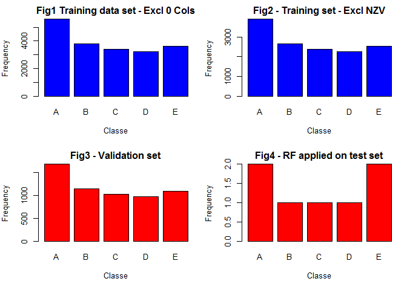

```r
#Rework results to plot
library(dplyr)
summary <- select(predDF, user_name, classe)
summary <- count(summary, user_name, classe)
#summary

x <- group_by(summary, classe, n)
x2 <- summarise(x)

#Notice difference in scale - explains the discrepancy
par(mfrow = c(2,2), mar = c(5,4,2,1))
plot(NewTrain$classe, col="blue", main="Fig1 Training data set - Excl 0 Cols", xlab="Classe", ylab="Frequency")
plot(FinalTrain$classe, col="blue", main="Fig2 - Training set - Excl NZV", xlab="Classe", ylab="Frequency")
plot(FinalValid$classe, col="red", main="Fig3 - Validation set", xlab="Classe", ylab="Frequency")
plot(x2$classe, col="red", main="Fig4 - RF applied on test set", xlab="Classe", ylab="Frequency")
```

## Comparisons

### References:

Ugulino, W.; Cardador, D.; Vega, K.; Velloso, E.; Milidiu, R.; Fuks, H. Wearable Computing: Accelerometers’ Data Classification of Body Postures and Movements. Proceedings of 21st Brazilian Symposium on Artificial Intelligence. Advances in Artificial Intelligence - SBIA 2012. In: Lecture Notes in Computer Science. , pp. 52-61. Curitiba, PR: Springer Berlin / Heidelberg, 2012. ISBN 978-3-642-34458-9. DOI: 10.1007/978-3-642-34459-6_6.

More information is available at this link: http://groupware.les.inf.puc-rio.br/har#ixzz3lMNG7T00

Cross Validation recommendations: *“Predictive Modeling with R and the caret Package” Author Max Kuhn, Ph.D* Jason Brownlee’s blog - http://machinelearningmastery.com